# Analyzing multiple runs of structure

This document shows how to use the R package `Rrunstruct` to use R to conduct multiple `structure` runs based on the parameters chosen for any parameter set specified in the `structure` front-end. It goes hand in hand with the computer practical in the SISG MCMC course. Before you follow this document, you will want to have completed the first part of the computer practical and have done at least one run of `structure` using the front-end.

The goal here is to see how to use some R tools to parse `structure` output to be able to quickly assess whether multiple runs of `structure's` MCMC algorithm give similar results. Along the way we will encounter a couple of challenges that arise, most notably the issue that the labels of the clusters may not be concordant across multiple `structure` runs. We might also take some time to look at some of the tools in today’s Hadley Wickham R ecosystem (`dplyr`, `ggplot2`, `tidyr`, `stringr`, etc.) that are helpful.

Before we can begin there is some setup you might have to do.

## Setup

You will need to install the package `Rrunstruct`. Because the package includes the `structure` executable file, it is not available on CRAN, but can be installed from GitHub. Doing so requires the `devtools` package.

```r
devtools::install_github("eriqande/Rrunstruct")
```

If that doesn’t work, it likely is because you need to get the `devtools` package and then try again:

```r
install.packages("devtools")
devtools::install_github("eriqande/Rrunstruct")
```

## Running Structure

To run `structure` you just need to:

1. load the package
2. set your R working directory to the directory inside the `structure` project that holds the parameter set you want to use. On my computer that is `~/Desktop/scot-cats/PlainPars`. On your computer, that path will have to be set accordingly.
3. Use the function`structure_runs()`, telling it where to put the output, what K values to use, how many reps for each, and the seed to use for the first run (this gets incremented by one for each successive run).

**A Big Note** The `mainparams` file in the PlainPars needs to have the RANDOMIZE variable set to 0 in order to set the random number generator seed to a different value for each run of `structure`. This can be achieved by running a set of runs through the scheduler using the front end. (Or by editing the `mainparams` file with a simple text editor.)

```r
library(Rrunstruct)
```

```r
setwd("~/Desktop/scot-cats/PlainPars")  # you've got to change this for your own computer!
```

```r
structure_runs(outdir = "struct-runs-from-r-1", K = 1:4, reps = 3, seed = 5566)
```

```
Launching structure. Writing stdout to file struct-runs-from-r-1/struct_stdout_K_1_rep_1 at Wed Jul 26 23:14:44 2017
Done with structure. Results written to file struct-runs-from-r-1/struct_results_K_1_rep_1 at Wed Jul 26 23:14:47 2017

Launching structure. Writing stdout to file struct-runs-from-r-1/struct_stdout_K_1_rep_2 at Wed Jul 26 23:14:47 2017
Done with structure. Results written to file struct-runs-from-r-1/struct_results_K_1_rep_2 at Wed Jul 26 23:14:49 2017

Launching structure. Writing stdout to file struct-runs-from-r-1/struct_stdout_K_1_rep_3 at Wed Jul 26 23:14:49 2017
Done with structure. Results written to file struct-runs-from-r-1/struct_results_K_1_rep_3 at Wed Jul 26 23:14:52 2017

Launching structure. Writing stdout to file struct-runs-from-r-1/struct_stdout_K_2_rep_1 at Wed Jul 26 23:14:52 2017
Done with structure. Results written to file struct-runs-from-r-1/struct_results_K_2_rep_1 at Wed Jul 26 23:14:55 2017

Launching structure. Writing stdout to file struct-runs-from-r-1/struct_stdout_K_2_rep_2 at Wed Jul 26 23:14:55 2017
Done with structure. Results written to file struct-runs-from-r-1/struct_results_K_2_rep_2 at Wed Jul 26 23:14:58 2017

Launching structure. Writing stdout to file struct-runs-from-r-1/struct_stdout_K_2_rep_3 at Wed Jul 26 23:14:58 2017
Done with structure. Results written to file struct-runs-from-r-1/struct_results_K_2_rep_3 at Wed Jul 26 23:15:01 2017

Launching structure. Writing stdout to file struct-runs-from-r-1/struct_stdout_K_3_rep_1 at Wed Jul 26 23:15:01 2017
Done with structure. Results written to file struct-runs-from-r-1/struct_results_K_3_rep_1 at Wed Jul 26 23:15:06 2017

Launching structure. Writing stdout to file struct-runs-from-r-1/struct_stdout_K_3_rep_2 at Wed Jul 26 23:15:06 2017
Done with structure. Results written to file struct-runs-from-r-1/struct_results_K_3_rep_2 at Wed Jul 26 23:15:10 2017

Launching structure. Writing stdout to file struct-runs-from-r-1/struct_stdout_K_3_rep_3 at Wed Jul 26 23:15:10 2017
Done with structure. Results written to file struct-runs-from-r-1/struct_results_K_3_rep_3 at Wed Jul 26 23:15:14 2017

Launching structure. Writing stdout to file struct-runs-from-r-1/struct_stdout_K_4_rep_1 at Wed Jul 26 23:15:14 2017
Done with structure. Results written to file struct-runs-from-r-1/struct_results_K_4_rep_1 at Wed Jul 26 23:15:18 2017

Launching structure. Writing stdout to file struct-runs-from-r-1/struct_stdout_K_4_rep_2 at Wed Jul 26 23:15:18 2017
Done with structure. Results written to file struct-runs-from-r-1/struct_results_K_4_rep_2 at Wed Jul 26 23:15:23 2017

Launching structure. Writing stdout to file struct-runs-from-r-1/struct_stdout_K_4_rep_3 at Wed Jul 26 23:15:23 2017
Done with structure. Results written to file struct-runs-from-r-1/struct_results_K_4_rep_3 at Wed Jul 26 23:15:28 2017
```

Once those runs have completed, you can take a look at what the outputs look like. All the output files should be in the directory `struct-runs-from-r-1` that is inside the `PlainPars` directory. Let’s see what they look like:

```r
dir(path = "struct-runs-from-r-1")
```

```
 [1] "struct_results_K_1_rep_1_f" "struct_results_K_1_rep_2_f" "struct_results_K_1_rep_3_f"
 [4] "struct_results_K_2_rep_1_f" "struct_results_K_2_rep_2_f" "struct_results_K_2_rep_3_f"
 [7] "struct_results_K_3_rep_1_f" "struct_results_K_3_rep_2_f" "struct_results_K_3_rep_3_f"
[10] "struct_results_K_4_rep_1_f" "struct_results_K_4_rep_2_f" "struct_results_K_4_rep_3_f"
[13] "struct_stdout_K_1_rep_1"    "struct_stdout_K_1_rep_2"    "struct_stdout_K_1_rep_3"
[16] "struct_stdout_K_2_rep_1"    "struct_stdout_K_2_rep_2"    "struct_stdout_K_2_rep_3"
[19] "struct_stdout_K_3_rep_1"    "struct_stdout_K_3_rep_2"    "struct_stdout_K_3_rep_3"
[22] "struct_stdout_K_4_rep_1"    "struct_stdout_K_4_rep_2"    "struct_stdout_K_4_rep_3"
```

The naming convention is pretty simple, `*results*` are the files that structure spits out at the end of each run. The `*stdout*` files store the stuff that the command line version of structure spits out. Let’s have a look at the first couple lines of the trace files:

```r
cat(readLines("struct-runs-from-r-1/struct_stdout_K_3_rep_1")[1:50], sep = "\n")
```

```
----------------------------------------------------
STRUCTURE by Pritchard, Stephens and Donnelly (2000)
     and Falush, Stephens and Pritchard (2003)
       Code by Pritchard, Falush and Hubisz
             Version 2.3.4 (Jul 2012)
----------------------------------------------------


Reading file "mainparams".
datafile is
/Users/eriq/Desktop/scot-cats/project_data
Reading file "extraparams".
Reading file "/Users/eriq/Desktop/scot-cats/project_data".
Number of alleles per locus: min= 9; ave=12.4; max=17


--------------------------------------

Finished initialization; starting MCMC
4000 iterations + 2000 burnin


 Rep#:    Alpha      F1    F2    F3       Ln Like
    1:    1.020    0.010 0.010 0.010      --
    2:    1.006    0.010 0.010 0.010      --
    3:    1.006    0.010 0.010 0.010      --
    4:    1.006    0.010 0.010 0.010      --
    5:    1.002    0.010 0.010 0.010      --
    6:    1.002    0.010 0.010 0.010      --
    7:    1.020    0.010 0.010 0.010      --
    8:    1.045    0.010 0.010 0.010      --
    9:    1.046    0.010 0.010 0.010      --

 Rep#:    Alpha      F1    F2    F3       Ln Like
   10:    1.033    0.010 0.010 0.010      --
   11:    1.060    0.010 0.010 0.010      --
   12:    1.064    0.010 0.010 0.010      --
   13:    1.101    0.010 0.010 0.010      --
   14:    1.067    0.010 0.010 0.010      --
   15:    1.062    0.010 0.010 0.010      --
   16:    1.060    0.010 0.010 0.010      --
   17:    1.030    0.010 0.010 0.010      --
   18:    1.004    0.010 0.013 0.010      --
   19:    1.004    0.010 0.013 0.010      --

 Rep#:    Alpha      F1    F2    F3       Ln Like
   20:    1.019    0.010 0.013 0.010      --
   21:    0.981    0.010 0.013 0.010      --
```

And look at a bit of one of the result files. Note that you are going to want to extract the “Inferred ancestry of individuals from this file”

```r
cat(readLines("struct-runs-from-r-1/struct_results_K_3_rep_1_f")[1:100], sep = "\n")
```

```
----------------------------------------------------
STRUCTURE by Pritchard, Stephens and Donnelly (2000)
     and Falush, Stephens and Pritchard (2003)
       Code by Pritchard, Falush and Hubisz
             Version 2.3.4 (Jul 2012)
----------------------------------------------------



Command line arguments:   /Library/Frameworks/R.framework/Versions/3.3/Resources/library/Rrunstruct/bin/structure_mac -K 3 -o struct-runs-from-r-1/struct_results_K_3_rep_1 -D 5572
Input File:    /Users/eriq/Desktop/scot-cats/project_data

Run parameters:
   304 individuals
   9 loci
   3 populations assumed
   2000 Burn-in period
   4000 Reps
RANDOMIZE turned off


--------------------------------------------
Proportion of membership of each pre-defined
 population in each of the 3 clusters

Given    Inferred Clusters       Number of
 Pop       1      2      3      Individuals

  1:     0.058  0.081  0.860       27
  2:     0.089  0.149  0.763       61
  3:     0.231  0.475  0.293       91
  4:     0.082  0.162  0.757       28
  5:     0.111  0.258  0.631       19
  6:     0.030  0.075  0.895        4
  7:     0.784  0.179  0.037       10
  8:     0.675  0.277  0.048       18
  9:     0.741  0.219  0.040       46
--------------------------------------------

Allele-freq. divergence among pops (Net nucleotide distance),
```

[output cut: 43 more lines]

```
 19      DB7    (0)    5 :  0.052 0.072 0.876
 20      DB8   (11)    3 :  0.886 0.088 0.026
 21      DB9    (0)    2 :  0.277 0.422 0.301
 22     DB10    (0)    3 :  0.332 0.608 0.059
 23     DB11    (0)    3 :  0.067 0.353 0.579
 24     DB12    (0)    1 :  0.074 0.080 0.846
 25     DB16    (0)    2 :  0.045 0.053 0.902
 26     DB17    (0)    3 :  0.108 0.071 0.821
 27     DB18    (0)    3 :  0.147 0.050 0.803
 28     DB19    (0)    3 :  0.048 0.923 0.029
 29     DB21   (22)    5 :  0.041 0.064 0.894
 30     DB22    (0)    2 :  0.111 0.109 0.780
 31     DB23    (0)    2 :  0.047 0.483 0.470
 32     DB24    (0)    3 :  0.547 0.410 0.043
 33     DB25    (0)    4 :  0.088 0.090 0.821
```

## Slurping up the Structure results

Although R’s syntax for text processing is perhaps not as compact as `awk` or `sed`, and it might be slower than `python` it has nice facilities for parsing text files. The package `stringr` used in combination with the function `readLines()` is particularly easy to use and helpful.

We won’t go into the details now though. Instead we have a single function that:

1. Reads in all the `stdout` and `results` files and wrangles them into long-format (tidy) data frames.
2. Identifies the cluster that each individual has the highest mean posterior Q for from each run.
3. For each rep determine the permutation of the cluster labels that makes the results the most congruent with the first rep. (This is a lightweight version of what the program CLUMPP does)
4. Creates columns in the data frame that have permuted versions of the cluster labels that can be used in plotting.

If you want the details of all that, you can check the package out on GitHub. I used the packages `tidyr` and `dplyr` extensively (but the code is still kind of ugly…).

Here we get all the output into a list of two data frames:

```r
L <- read_and_process_structure_output("struct-runs-from-r-1")
```

And let’s take a look at the tops of the two data frames in that list.

### Q values

First, the estimated Q values from each individual

```r
L$q
```

| K | Rep | Index | Label | Miss | Pop | cluster | probability | mp | cluster_relabeled |
| --- | --- | --- | --- | --- | --- | --- | --- | --- | --- |
| 1 | 1 | 1 | Z12 | 0 | 3 | 1 | 1.000 | 1 | 1 |
| 1 | 1 | 2 | Z13 | 0 | 3 | 1 | 1.000 | 1 | 1 |
| 1 | 1 | 3 | Z14 | 0 | 3 | 1 | 1.000 | 1 | 1 |
| 1 | 1 | 4 | Z15 | 0 | 3 | 1 | 1.000 | 1 | 1 |
| 1 | 1 | 5 | Z16 | 0 | 3 | 1 | 1.000 | 1 | 1 |
| 1 | 1 | 6 | Z17 | 0 | 1 | 1 | 1.000 | 1 | 1 |
| 1 | 1 | 7 | Z18 | 0 | 3 | 1 | 1.000 | 1 | 1 |
| 1 | 1 | 8 | Z19 | 0 | 3 | 1 | 1.000 | 1 | 1 |
| 1 | 1 | 9 | Z20 | 11 | 2 | 1 | 1.000 | 1 | 1 |
| 1 | 1 | 10 | Z21 | 0 | 2 | 1 | 1.000 | 1 | 1 |

[output cut: 990 more lines]

The columns `K` and `Rep` just give the K-value assumed in the structure run, and which replicate the run was. `Index` is just the numerical index of the individual, `Label` is the label given to the individual sample, `Miss` is the percentage of loci missing data in that individual, `Pop` is the putative popuation or sampling location of the individual (as given in the data input), `cluster` gives the cluster that the `probability` refers to. `probability` is the posterior mean of the Q value for the given cluster. `mp` is the number of the label permutation that makes the results of this replicate as congruent as possible with replicate #1. Finally `cluster_relabeled` is the label of the cluster, once the clusters have been relabeled to be congruent with replicate #1. We will explore that further.

### Traces

Here we look at the traces:

```r
L$traces
```

| K | Rep | Sweep | variable | value | mp | variables_relabeled |
| --- | --- | --- | --- | --- | --- | --- |
| 1 | 1 | 1 | Alpha | 0.998 | 1 | Alpha |
| 1 | 1 | 2 | Alpha | 0.977 | 1 | Alpha |
| 1 | 1 | 3 | Alpha | 1.023 | 1 | Alpha |
| 1 | 1 | 4 | Alpha | 1.035 | 1 | Alpha |
| 1 | 1 | 5 | Alpha | 1.089 | 1 | Alpha |
| 1 | 1 | 6 | Alpha | 1.134 | 1 | Alpha |
| 1 | 1 | 7 | Alpha | 1.092 | 1 | Alpha |
| 1 | 1 | 8 | Alpha | 1.032 | 1 | Alpha |
| 1 | 1 | 9 | Alpha | 1.012 | 1 | Alpha |
| 1 | 1 | 10 | Alpha | 1.039 | 1 | Alpha |

[output cut: 990 more lines]

The columns `K`, `Rep`, and `mp` are as above. `Sweep` tells us which sweep the row refers to. It runs from 1 to 6000 in this case—it includes sweeps from the burn-in period. `variable` tells us what variable we are looking at. Here, those are either “Alpha” (the $\alpha$ variable) or one of the $F$ parameters (i.e. F1, F2, etc). `variables_relabeled` has the name of the variable after they have been relabeled to be (more or less) congruent with replicate 1. `value` is the value of that variable.

## Plotting the traces

Once structure’s outputs are in this type of long-format data frame, it is relatively easy to plot and compare between runs.

### Alpha

First we will plot the traces of $\alpha$ and the $F$ parameters and see how the compare across runs.

Here are the $\alpha$’s:

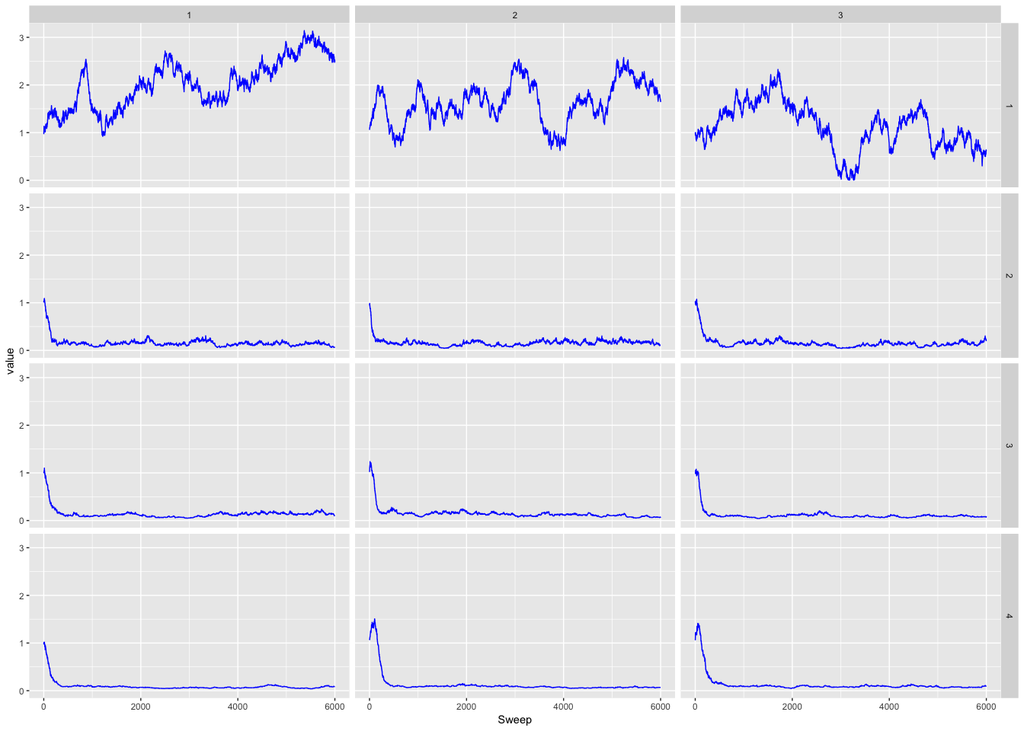

```r
ggplot(L$traces %>% filter(variable == "Alpha"), aes(x = Sweep, y = value)) +
  geom_line(colour = "blue") +
  facet_grid(K ~ Rep)
```

That is interesting. Not surprisingly, when K is 1, $\alpha$ meanders all over because it is not really used in the model when K is 1, so there is nothing constraining it.

For $K>1$ the results look pretty similar between the reps. But, let’s focus on $K>1$:

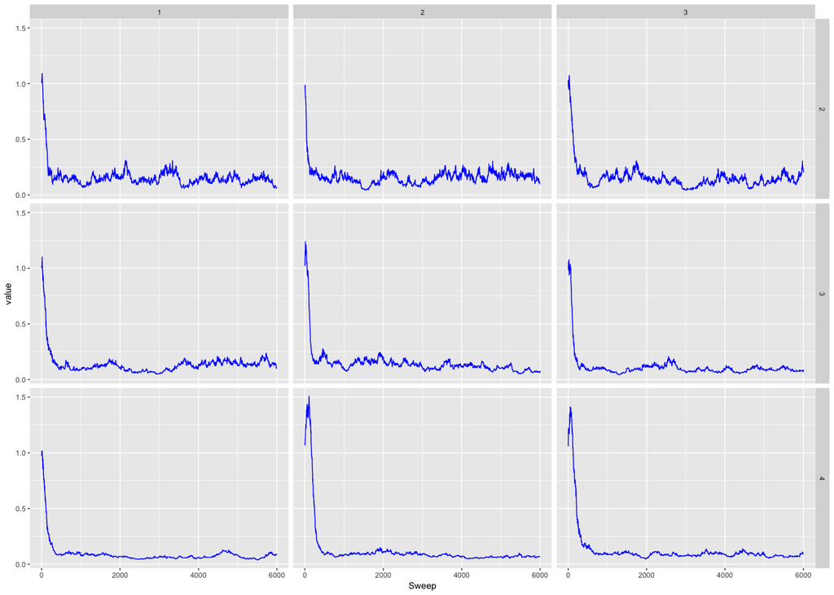

```r
ggplot(L$traces %>% filter(variable == "Alpha", K != 1), aes(x = Sweep, y = value)) +
  geom_line(colour = "blue") +
  facet_grid(K ~ Rep)
```

### F’s

When we look at the values of F, we see the labeling issue:

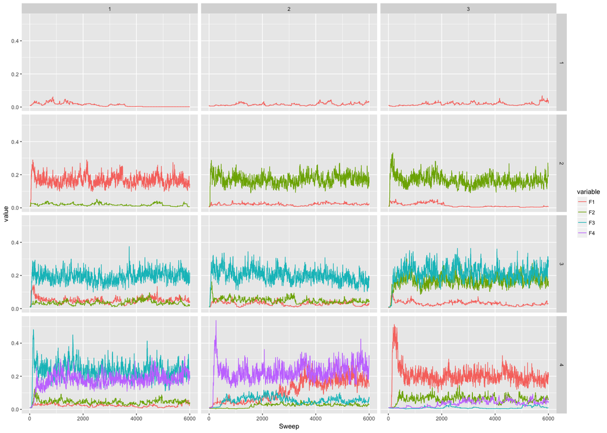

```r
ggplot(L$traces %>% filter(str_detect(variable, "^F")), aes(x = Sweep, y = value, colour = variable)) +
  geom_line() +
  facet_grid(K ~ Rep)
```

When $K>1$ the colors don’t match up because the clusters don’t have the same name. We can rectify that by using the relabeled version:

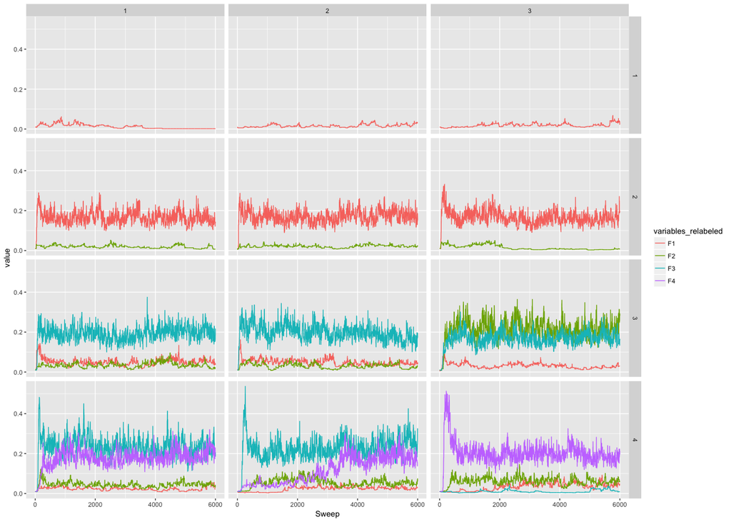

```r
ggplot(L$traces %>% filter(str_detect(variables_relabeled, "^F")), aes(x = Sweep, y = value, colour = variables_relabeled)) +
  geom_line() +
  facet_grid(K ~ Rep)
```

We see that the course of the F variables during MCMC looks similar between reps for K=1 and K=2 but quite different between reps for K>2. We contend that the runs for K>2 might have to be run for much longer (and even then they may not converge to the same place, reliably).

## Plotting the Q values

Often what we are really interested in are the Q values for different individuals. It is thus important to assess how much those differ between runs. One way to do that is to plot the estimated Q values in each rep > 1 with those in the first rep. To do that, we can add the rep1 results (at each K) to the data frame of results:

```r
Qs <- L$q %>%
  filter(Rep == 1) %>%  # get just the first rep
  group_by(K, Index, cluster_relabeled) %>% # group by these to preserve the columns
  transmute(rep1_cluster = cluster_relabeled, rep1_prob = probability) %>% # rename columns
  ungroup %>%
  inner_join(L$q) %>%  # slap those values back on the original data frame matching K and Rep
  filter(Rep != 1) %>% # toss out the rows comparing Rep 1 to Rep 1
  mutate(which_cluster = paste(rep1_cluster))  # name a new column with something better for the plot
```

Here is what that data frame looks like:

```r
Qs
```

| K | Index | cluster_relabeled | rep1_cluster | rep1_prob | Rep | Label | Miss | Pop | cluster | probability | mp | which_cluster |
| --- | --- | --- | --- | --- | --- | --- | --- | --- | --- | --- | --- | --- |
| 1 | 1 | 1 | 1 | 1.000 | 2 | Z12 | 0 | 3 | 1 | 1.000 | 1 | 1 |
| 1 | 1 | 1 | 1 | 1.000 | 3 | Z12 | 0 | 3 | 1 | 1.000 | 1 | 1 |
| 1 | 2 | 1 | 1 | 1.000 | 2 | Z13 | 0 | 3 | 1 | 1.000 | 1 | 1 |
| 1 | 2 | 1 | 1 | 1.000 | 3 | Z13 | 0 | 3 | 1 | 1.000 | 1 | 1 |
| 1 | 3 | 1 | 1 | 1.000 | 2 | Z14 | 0 | 3 | 1 | 1.000 | 1 | 1 |
| 1 | 3 | 1 | 1 | 1.000 | 3 | Z14 | 0 | 3 | 1 | 1.000 | 1 | 1 |
| 1 | 4 | 1 | 1 | 1.000 | 2 | Z15 | 0 | 3 | 1 | 1.000 | 1 | 1 |
| 1 | 4 | 1 | 1 | 1.000 | 3 | Z15 | 0 | 3 | 1 | 1.000 | 1 | 1 |
| 1 | 5 | 1 | 1 | 1.000 | 2 | Z16 | 0 | 3 | 1 | 1.000 | 1 | 1 |
| 1 | 5 | 1 | 1 | 1.000 | 3 | Z16 | 0 | 3 | 1 | 1.000 | 1 | 1 |

[output cut: 990 more lines]

And now it is easy to compare the Q values in each Rep after Rep 1 with the Q values in Rep 1:

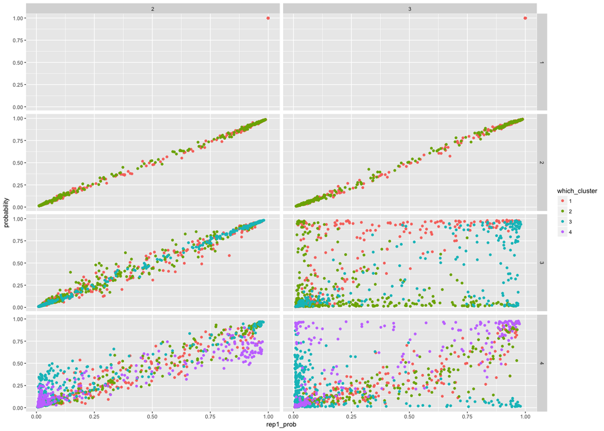

```r
ggplot(Qs, aes(x = rep1_prob, y = probability, colour = which_cluster)) +
  geom_point() +
  facet_grid(K ~ Rep)
```

This is interesting as it shows that for K=2 the three runs all converged to pretty much the same Q values. The “wiggle” off the $y=x$ line there is due to Monte Carlo variance, but not caused from the chains converging to very different parts of the space, as is clear what has happened for some of the replicates for K=3 and K=4.

## Longer runs at K = 2

Let’s see if we can tighten up that Monte Carlo variance be doing longer runs. I have made a new directory `LongerRun` with the `structure` GUI and set it up to to 5000 burn in and 45000 sweeps after burn in. Once again, you have to ensure that the RANDOMIZE setting in the `mainparams` file in that directory is set to 0. Let’s do 4 reps at K=2 to see how that works out.

```r
# do the runs
setwd("~/Desktop/scot-cats/LongerRun")  # this must be changed on other computers
```

```
The working directory was changed to /Users/eriq/Desktop/scot-cats/LongerRun inside a notebook chunk. The working directory will be reset when the chunk is finished running. Use the knitr root.dir option in the setup chunk to change the the working directory for notebook chunks.
```

```r
structure_runs(outdir = "r-runs-2", K = 2, reps = 4, seed = 9876)
```

```
Launching structure. Writing stdout to file r-runs-2/struct_stdout_K_2_rep_1 at Wed Jul 26 23:15:48 2017
Done with structure. Results written to file r-runs-2/struct_results_K_2_rep_1 at Wed Jul 26 23:16:17 2017

Launching structure. Writing stdout to file r-runs-2/struct_stdout_K_2_rep_2 at Wed Jul 26 23:16:17 2017
Done with structure. Results written to file r-runs-2/struct_results_K_2_rep_2 at Wed Jul 26 23:16:48 2017

Launching structure. Writing stdout to file r-runs-2/struct_stdout_K_2_rep_3 at Wed Jul 26 23:16:48 2017
Done with structure. Results written to file r-runs-2/struct_results_K_2_rep_3 at Wed Jul 26 23:17:17 2017

Launching structure. Writing stdout to file r-runs-2/struct_stdout_K_2_rep_4 at Wed Jul 26 23:17:17 2017
Done with structure. Results written to file r-runs-2/struct_results_K_2_rep_4 at Wed Jul 26 23:17:47 2017
```

Then slurp up the results

```r
setwd("~/Desktop/scot-cats/LongerRun")  # this must be changed on other computers
```

```
The working directory was changed to /Users/eriq/Desktop/scot-cats/LongerRun inside a notebook chunk. The working directory will be reset when the chunk is finished running. Use the knitr root.dir option in the setup chunk to change the the working directory for notebook chunks.
```

```r
L2 <- read_and_process_structure_output("r-runs-2")
```

```
reading files
finding label permutations for the reps
relabeling the traces and results
```

Then, compare rep 1 to the others:

```r
# format the data frame
Qs2 <- L2$q %>%
  filter(Rep == 1) %>%  # get just the first rep
  group_by(K, Index, cluster_relabeled) %>% # group by these to preserve the columns
  transmute(rep1_cluster = cluster_relabeled, rep1_prob = probability) %>% # rename columns
  ungroup %>%
  inner_join(L2$q) %>%  # slap those values back on the original data frame matching K and Rep
  filter(Rep != 1) %>% # toss out the rows comparing Rep 1 to Rep 1
  mutate(which_cluster = paste(rep1_cluster))  # name a new column with something better for the plot
```

Plot those up:

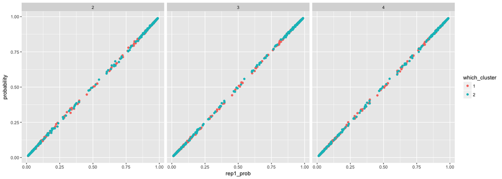

```r
ggplot(Qs2, aes(x = rep1_prob, y = probability, colour = which_cluster)) +
  geom_point() +
  facet_wrap( ~ Rep, ncol = 3)
```